# Le test de Student pas à pas

Jacques van Helden

18 January 2016

## Téléchargement d’une table de données d’expression

Ouvrez une fenêtre de votre navigateur, et connectez-vous au site du cours d’analyse statistique des données génomiques:

http://pedagogix-tagc.univ-mrs.fr/courses/ASG1/data/marrays

Téléchargez sur votre ordinateur les fichiers suivants:

| Fichier | Contenu |
| --- | --- |
| GSE13425_Norm_Whole.txt | Table d’expression (une ligne par gène, une colonne par patient) |
| phenoData_GSE13425.tab | Description des échantillons, une ligne par échantillon, un colonne par attribut |

Pour ce TP, nous supposerons que les deux tables ont été sauvegardées sur votre disque dur , dans un sous-dossier de votre bureau nommé TP_BIOINFOAPP.

## Télécharger les génotypes des patients

Nous allons maintenant charger dans R les tables que nous venons de télécharger sur notre disque dur.

```r
## Charger la table de données dans une variable de type data.frame
denboer.expr <- read.delim(
  file = "~/Desktop/tp_bioinfoapp/GSE13425_Norm_Whole.txt",
  row.names = 1)
```

Après avoir chargé une table de données, le premier réflexe est de vérifier son contenu.

Pour cela nous pouvons

- mesurer ses dimensions avec la fonction *dim()*

```r
dim(denboer.expr)
```

```
## [1] 22283   190
```

- afficher les premières lignes de la table

```r
head(denboer.expr)
```

```
##                  GSM338666 GSM338667 GSM338668 GSM338669 GSM338670
## DDR1|1007_s_at        4.38      4.38      4.23      3.98      5.12
## RFC2|1053_at          3.44      3.33      3.73      3.58      3.40
## HSPA6|117_at          2.51      2.62      2.37      2.43      2.49
## PAX8|121_at           6.24      6.21      6.10      6.09      6.53
## GUCA1A|1255_g_at      2.29      2.23      2.17      2.26      2.27
## UBA7|1294_at          5.57      5.83      5.46      5.20      6.83
##                  GSM338671 GSM338672 GSM338673 GSM338674 GSM338675
## DDR1|1007_s_at        3.90      4.18      4.23      4.20      4.21
## RFC2|1053_at          3.07      3.02      3.37      2.97      3.22
## HSPA6|117_at          2.57      2.69      2.74      2.40      2.59
## PAX8|121_at           6.18      6.58      6.12      6.02      6.14
## GUCA1A|1255_g_at      2.18      2.15      2.11      2.21      2.40
## UBA7|1294_at          5.22      6.12      5.06      5.33      5.65
##                  GSM338676 GSM338677 GSM338678 GSM338679 GSM338680
## DDR1|1007_s_at        4.16      4.78      4.37      4.24      4.19
## RFC2|1053_at          3.20      3.04      3.80      3.13      3.39
## HSPA6|117_at          2.81      2.70      2.70      2.39      3.48
## PAX8|121_at           6.01      6.38      6.03      6.22      6.07
## GUCA1A|1255_g_at      2.06      2.17      2.21      2.06      2.10
## UBA7|1294_at          5.05      5.51      5.69      5.55      5.31
##                  GSM338681 GSM338682 GSM338683 GSM338684 GSM338685
## DDR1|1007_s_at        4.44      4.15      3.98      3.84      4.32
## RFC2|1053_at          3.14      3.09      3.35      3.35      3.69
## HSPA6|117_at          2.50      2.27      2.42      2.69      2.33
## PAX8|121_at           6.08      6.04      5.99      6.12      6.17
## GUCA1A|1255_g_at      2.13      2.09      2.15      2.15      2.23
## UBA7|1294_at          5.48      4.89      6.06      5.19      5.03
##                  GSM338686 GSM338687 GSM338688 GSM338689 GSM338690
## DDR1|1007_s_at        4.11      4.20      4.04      4.17      4.41
## RFC2|1053_at          3.97      3.04      3.25      4.20      3.04
## HSPA6|117_at          2.33      2.27      2.42      2.14      2.75
## PAX8|121_at           5.94      6.07      5.97      5.83      6.21
## GUCA1A|1255_g_at      1.97      2.08      2.19      2.10      2.24
## UBA7|1294_at          4.98      5.20      6.01      5.53      5.26
##                  GSM338691 GSM338692 GSM338693 GSM338694 GSM338695
## DDR1|1007_s_at        3.98      4.12      3.80      4.16      3.96
## RFC2|1053_at          3.10      3.29      3.47      3.42      3.45
## HSPA6|117_at          3.73      2.42      2.23      3.49      4.42
## PAX8|121_at           6.06      6.21      5.81      5.87      6.42
```

[output cut: 211 more lines]

```
## UBA7|1294_at          5.56      5.79      5.60      5.61      5.64
##                  GSM338846 GSM338847 GSM338848 GSM338849 GSM338850
## DDR1|1007_s_at        4.47      4.88      5.73      5.55      4.15
## RFC2|1053_at          2.90      3.40      3.04      2.88      2.88
## HSPA6|117_at          2.61      2.31      2.48      2.68      4.09
## PAX8|121_at           6.21      6.01      6.20      6.34      6.39
## GUCA1A|1255_g_at      2.36      2.06      2.14      2.24      2.27
## UBA7|1294_at          5.48      6.29      5.69      5.67      5.34
##                  GSM338851 GSM338852 GSM338853 GSM338854 GSM338855
## DDR1|1007_s_at        6.16      4.23      5.18      4.68      4.55
## RFC2|1053_at          2.89      3.34      3.02      3.07      2.99
## HSPA6|117_at          2.65      2.83      2.66      2.54      2.64
## PAX8|121_at           6.25      6.05      6.30      6.38      6.25
## GUCA1A|1255_g_at      2.27      2.25      2.14      2.23      2.16
## UBA7|1294_at          5.34      5.98      6.73      5.72      5.57
```

```r
denboer.expr[1:5,27:30]
```

```
##                  GSM338692 GSM338693 GSM338694 GSM338695
## DDR1|1007_s_at        4.12      3.80      4.16      3.96
## RFC2|1053_at          3.29      3.47      3.42      3.45
## HSPA6|117_at          2.42      2.23      3.49      4.42
## PAX8|121_at           6.21      5.81      5.87      6.42
## GUCA1A|1255_g_at      2.25      2.09      2.16      2.29
```

```r
denboer.expr["HSPA6|117_at","GSM338697"]
```

```
## [1] 2.42
```

Nous pouvons calculer le niveau moyen d’expression pour l’ensemble de la table de données. La fonction *mean()* calcule la moyenne d’un vecteur de nombres. Le problème est que la table de données n’est pas un vecteur, mais une structure de type *data.frame* (matrice avec des noms de lignes et de colonnes). Pour convertir cette matrice en vecteur, nous utilisons la formule magique *as.vector(as.matrix(…))*

```r
## Générer un vecteur qui contient toutes les valeurs d'expression
denboer.expr.vector <- as.vector(as.matrix(denboer.expr))
length(denboer.expr.vector)
```

```
## [1] 4233770
```

```r
dim(denboer.expr) ## Calculer les dimensions de la data.frame d'expression
```

```
## [1] 22283   190
```

```r
prod(dim(denboer.expr)) ## Le produit des nb de colonnes et de lignes de la table d'expression égale la longueur du vecteur (vérification)
```

```
## [1] 4233770
```

```r
## Compute the mean, variance and standard deviation for the whole expression table
mean(denboer.expr.vector)
```

```
## [1] 3.711429
```

```r
sd(denboer.expr.vector) ## écart-type (standard deviation)
```

```
## [1] 1.621904
```

```r
var(denboer.expr.vector) ## variance
```

```
## [1] 2.630572
```

## Calculer les moyennes d’expression par gène

Nous allons dessiner un graphique comparant la moyenne (abscisse) et l’écart-type (ordonnée) d’expression pour chaque gène (chaque gène sera représenté par un point).

Pour appliquer un clacul à chaque ligne de la table de données (chaque gène), nous utilisons la fonction R *apply()*.

```r
## Calculer la moyenne de chaque gène (ligne) et conserver le résultat dans une variable nommée"mean.per.gene"
mean.per.gene <- apply(X = denboer.expr, MARGIN = 1, FUN = mean)
class(mean.per.gene) ## Retourne un vecteur de valeurs numériques
```

```
## [1] "numeric"
```

```r
length (mean.per.gene)
```

```
## [1] 22283
```

```r
## Idem pour 'écart-type (sd = standard deviation)
sd.per.gene <- apply(X = denboer.expr, MARGIN = 1, FUN = sd)

## La fonction "apply" permet également d'appliquer une fonction sur chaque colonne d'un tableau de données
mean.per.sample <- apply(X = denboer.expr, MARGIN = 2, FUN = mean)
length(mean.per.sample)
```

```
## [1] 190
```

Nous allons maintenant dessiner un nuage de points pour comparer les moyennes et écart-types par gène.

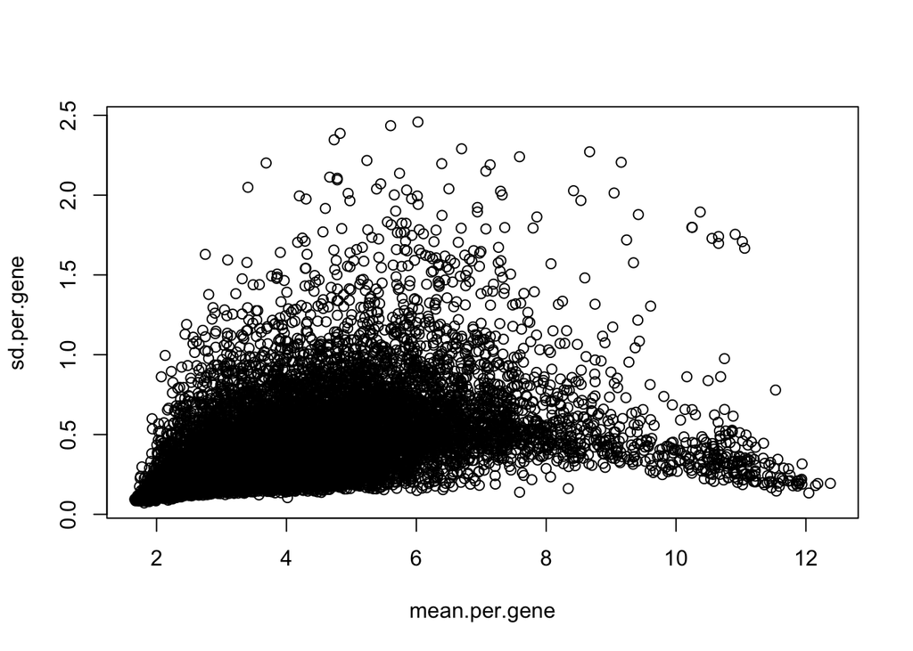

```r
plot(mean.per.gene, sd.per.gene)
```

## Lecture des types de leucémies

Nous allons charger une table indiquant les types de leucémies associées) chaque patient.

http://dputhier.github.io/jgb71e-polytech-bioinfo-app/

La table fournissant la description détaillée de chaque échantillon se trouve à l’URL suivant:

http://dputhier.github.io/jgb71e-polytech-bioinfo-app/practical/microarrays/denboer_data/GSE13425_phenoData.txt

```r
sample.descriptions <- read.delim(file = "http://dputhier.github.io/jgb71e-polytech-bioinfo-app/practical/microarrays/denboer_data/GSE13425_phenoData.txt", row.names = 1)

dim(sample.descriptions)
```

```
## [1] 190   4
```

```r
colnames(sample.descriptions)
```

```
## [1] "Sample_title"               "Sample_source_name_ch1"
## [3] "Sample_characteristics_ch1" "Sample_description"
```

```r
rownames(sample.descriptions)
```

```
##   [1] "GSM338666" "GSM338667" "GSM338668" "GSM338669" "GSM338670"
##   [6] "GSM338671" "GSM338672" "GSM338673" "GSM338674" "GSM338675"
##  [11] "GSM338676" "GSM338677" "GSM338678" "GSM338679" "GSM338680"
##  [16] "GSM338681" "GSM338682" "GSM338683" "GSM338684" "GSM338685"
##  [21] "GSM338686" "GSM338687" "GSM338688" "GSM338689" "GSM338690"
##  [26] "GSM338691" "GSM338692" "GSM338693" "GSM338694" "GSM338695"
##  [31] "GSM338696" "GSM338697" "GSM338698" "GSM338699" "GSM338700"
##  [36] "GSM338701" "GSM338702" "GSM338703" "GSM338704" "GSM338705"
##  [41] "GSM338706" "GSM338707" "GSM338708" "GSM338709" "GSM338710"
##  [46] "GSM338711" "GSM338712" "GSM338713" "GSM338714" "GSM338715"
##  [51] "GSM338716" "GSM338717" "GSM338718" "GSM338719" "GSM338720"
##  [56] "GSM338721" "GSM338722" "GSM338723" "GSM338724" "GSM338725"
##  [61] "GSM338726" "GSM338727" "GSM338728" "GSM338729" "GSM338730"
##  [66] "GSM338731" "GSM338732" "GSM338733" "GSM338734" "GSM338735"
##  [71] "GSM338736" "GSM338737" "GSM338738" "GSM338739" "GSM338740"
```

[output cut: 23 more lines]

## Choix de deux groupes (sous-types de leucémies) pour l’analyse différentielle

```r
## Afficher le contenu de la colonne "Sample_title" de la table sample.descriptions

## Les trois commandes suivantes donnent le même résultat (seule la syntaxe diffère)
print(sample.descriptions[,1])
```

```
##   [1] T-ALL                    T-ALL
##   [3] T-ALL                    T-ALL
##   [5] T-ALL                    T-ALL
##   [7] T-ALL                    T-ALL
##   [9] T-ALL                    T-ALL
##  [11] T-ALL                    T-ALL
##  [13] T-ALL                    T-ALL
##  [15] T-ALL                    T-ALL
##  [17] T-ALL                    T-ALL
##  [19] T-ALL                    T-ALL
##  [21] T-ALL                    T-ALL
##  [23] T-ALL                    T-ALL
##  [25] T-ALL                    T-ALL
##  [27] T-ALL                    T-ALL
##  [29] T-ALL                    T-ALL
```

[output cut: 81 more lines]

```r
print(sample.descriptions[,"Sample_title"])
```

```
##   [1] T-ALL                    T-ALL
##   [3] T-ALL                    T-ALL
##   [5] T-ALL                    T-ALL
##   [7] T-ALL                    T-ALL
##   [9] T-ALL                    T-ALL
##  [11] T-ALL                    T-ALL
##  [13] T-ALL                    T-ALL
##  [15] T-ALL                    T-ALL
##  [17] T-ALL                    T-ALL
##  [19] T-ALL                    T-ALL
##  [21] T-ALL                    T-ALL
##  [23] T-ALL                    T-ALL
##  [25] T-ALL                    T-ALL
##  [27] T-ALL                    T-ALL
##  [29] T-ALL                    T-ALL
```

[output cut: 81 more lines]

```r
print(sample.descriptions$Sample_title)
```

```
##   [1] T-ALL                    T-ALL
##   [3] T-ALL                    T-ALL
##   [5] T-ALL                    T-ALL
##   [7] T-ALL                    T-ALL
##   [9] T-ALL                    T-ALL
##  [11] T-ALL                    T-ALL
##  [13] T-ALL                    T-ALL
##  [15] T-ALL                    T-ALL
##  [17] T-ALL                    T-ALL
##  [19] T-ALL                    T-ALL
##  [21] T-ALL                    T-ALL
##  [23] T-ALL                    T-ALL
##  [25] T-ALL                    T-ALL
##  [27] T-ALL                    T-ALL
##  [29] T-ALL                    T-ALL
```

[output cut: 81 more lines]

```r
## Générer une table de fréquences indiquant le nombre d'occurrences de chaque sous-type de leucémie dans les 190 échantillons de DenBoer
table(sample.descriptions$Sample_title)
```

```
##
##                  BCR-ABL  BCR-ABL + hyperdiploidy   E2A-rearranged (E-sub)
##                        4                        1                        4
##       E2A-rearranged (E)      E2A-rearranged (EP)             hyperdiploid
##                        1                        8                       44
##                      MLL                pre-B ALL                    T-ALL
##                        4                       44                       36
##                 TEL-AML1 TEL-AML1 + hyperdiploidy
##                       43                        1
```

```r
## Choisissons arbitrairement de nous intéresser aux deux groupes suivants
group1 <- "TEL-AML1"
group2 <- "hyperdiploid"

## Identification des échantillons (colonnes de la table d'expression) dont le type correspond au groupe 1
sample.descriptions$Sample_title == group1
```

```
##   [1] FALSE FALSE FALSE FALSE FALSE FALSE FALSE FALSE FALSE FALSE FALSE
##  [12] FALSE FALSE FALSE FALSE FALSE FALSE FALSE FALSE FALSE FALSE FALSE
##  [23] FALSE FALSE FALSE FALSE FALSE FALSE FALSE FALSE FALSE FALSE FALSE
##  [34] FALSE FALSE FALSE  TRUE  TRUE  TRUE  TRUE  TRUE  TRUE  TRUE  TRUE
##  [45]  TRUE  TRUE  TRUE  TRUE  TRUE  TRUE  TRUE  TRUE  TRUE  TRUE  TRUE
##  [56]  TRUE  TRUE  TRUE  TRUE  TRUE  TRUE  TRUE  TRUE  TRUE  TRUE  TRUE
##  [67]  TRUE  TRUE  TRUE  TRUE  TRUE  TRUE  TRUE  TRUE  TRUE  TRUE  TRUE
##  [78]  TRUE  TRUE FALSE FALSE FALSE FALSE FALSE FALSE FALSE FALSE FALSE
##  [89] FALSE FALSE FALSE FALSE FALSE FALSE FALSE FALSE FALSE FALSE FALSE
## [100] FALSE FALSE FALSE FALSE FALSE FALSE FALSE FALSE FALSE FALSE FALSE
## [111] FALSE FALSE FALSE FALSE FALSE FALSE FALSE FALSE FALSE FALSE FALSE
## [122] FALSE FALSE FALSE FALSE FALSE FALSE FALSE FALSE FALSE FALSE FALSE
## [133] FALSE FALSE FALSE FALSE FALSE FALSE FALSE FALSE FALSE FALSE FALSE
## [144] FALSE FALSE FALSE FALSE FALSE FALSE FALSE FALSE FALSE FALSE FALSE
## [155] FALSE FALSE FALSE FALSE FALSE FALSE FALSE FALSE FALSE FALSE FALSE
## [166] FALSE FALSE FALSE FALSE FALSE FALSE FALSE FALSE FALSE FALSE FALSE
## [177] FALSE FALSE FALSE FALSE FALSE FALSE FALSE FALSE FALSE FALSE FALSE
## [188] FALSE FALSE FALSE
```

```r
sample.descriptions$Sample_title == group2
```

```
##   [1] FALSE FALSE FALSE FALSE FALSE FALSE FALSE FALSE FALSE FALSE FALSE
##  [12] FALSE FALSE FALSE FALSE FALSE FALSE FALSE FALSE FALSE FALSE FALSE
##  [23] FALSE FALSE FALSE FALSE FALSE FALSE FALSE FALSE FALSE FALSE FALSE
##  [34] FALSE FALSE FALSE FALSE FALSE FALSE FALSE FALSE FALSE FALSE FALSE
##  [45] FALSE FALSE FALSE FALSE FALSE FALSE FALSE FALSE FALSE FALSE FALSE
##  [56] FALSE FALSE FALSE FALSE FALSE FALSE FALSE FALSE FALSE FALSE FALSE
##  [67] FALSE FALSE FALSE FALSE FALSE FALSE FALSE FALSE FALSE FALSE FALSE
##  [78] FALSE FALSE FALSE  TRUE  TRUE  TRUE  TRUE  TRUE  TRUE  TRUE  TRUE
##  [89]  TRUE  TRUE  TRUE  TRUE  TRUE  TRUE  TRUE  TRUE  TRUE  TRUE  TRUE
## [100]  TRUE  TRUE  TRUE  TRUE  TRUE  TRUE  TRUE  TRUE  TRUE  TRUE  TRUE
## [111]  TRUE  TRUE  TRUE  TRUE  TRUE  TRUE  TRUE  TRUE  TRUE  TRUE  TRUE
## [122]  TRUE  TRUE  TRUE FALSE FALSE FALSE FALSE FALSE FALSE FALSE FALSE
## [133] FALSE FALSE FALSE FALSE FALSE FALSE FALSE FALSE FALSE FALSE FALSE
## [144] FALSE FALSE FALSE FALSE FALSE FALSE FALSE FALSE FALSE FALSE FALSE
## [155] FALSE FALSE FALSE FALSE FALSE FALSE FALSE FALSE FALSE FALSE FALSE
## [166] FALSE FALSE FALSE FALSE FALSE FALSE FALSE FALSE FALSE FALSE FALSE
## [177] FALSE FALSE FALSE FALSE FALSE FALSE FALSE FALSE FALSE FALSE FALSE
## [188] FALSE FALSE FALSE
```

## Extraction de sous-ensembles de la table d’expression correspondant à deux sous-types de leucémies

```r
## Sélection d'une sous-table contenant uniquement les valeurs d'expression du groupe 1
expr.group1 <- denboer.expr[, sample.descriptions$Sample_title == group1]
dim(expr.group1)
```

```
## [1] 22283    43
```

```r
## Sélection d'une sous-table contenant uniquement les valeurs d'expression du groupe 2
expr.group2 <- denboer.expr[, sample.descriptions$Sample_title == group2]
dim(expr.group2)
```

```
## [1] 22283    44
```

## Comparaison des moyennes d’expression entre 2 groupes

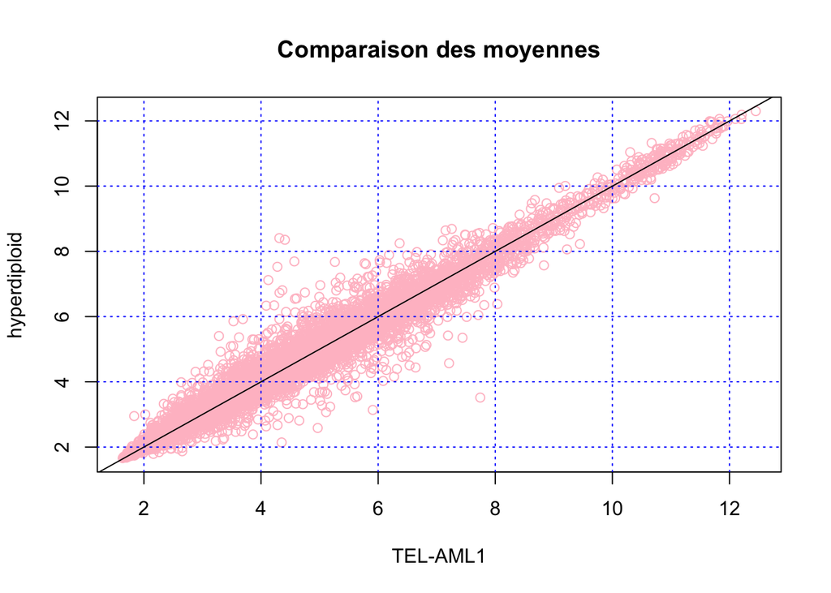

```r
mean.per.gene.group1 <- apply(X = expr.group1, MARGIN = 1, FUN = mean)
mean.per.gene.group2 <- apply(X = expr.group2, MARGIN = 1, FUN = mean)
plot(mean.per.gene.group1, mean.per.gene.group2,
     main="Comparaison des moyennes",
     xlab=group1, ylab=group2,
     col="pink")
grid(col="blue")
abline(a=0, b=1)
```

## Contrôle négatif: permutations des valeurs par ligne

```r
## Appliquer à chaque ligne de la table d'expression (gène) une permutation aléatoire des valeurs (sample)
rand <- t(apply(denboer.expr, MARGIN = 1, sample))
dim(rand)
```

```
## [1] 22283   190
```

```r
## Sélectionner les mêmes colonnes que précédemment, mais sur les données permutées
rand1 <- rand[, sample.descriptions$Sample_title == group1]
dim(rand1)
```

```
## [1] 22283    43
```

```r
rand2 <- rand[, sample.descriptions$Sample_title == group2]
dim(rand2)
```

```
## [1] 22283    44
```

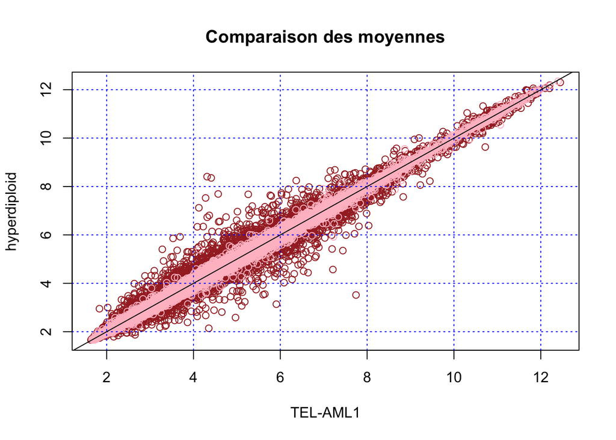

```r
mean.per.gene.rand1 <- apply(rand1, MARGIN = 1, FUN = mean)
mean.per.gene.rand2 <- apply(rand2, MARGIN = 1, FUN = mean)

plot(mean.per.gene.group1, mean.per.gene.group2,
     main="Comparaison des moyennes",
     xlab=group1, ylab=group2,
     col="brown")
lines(mean.per.gene.rand1, mean.per.gene.rand2, col="pink", type="p")
grid(col="blue")
abline(a=0, b=1)
```

## Plot MA

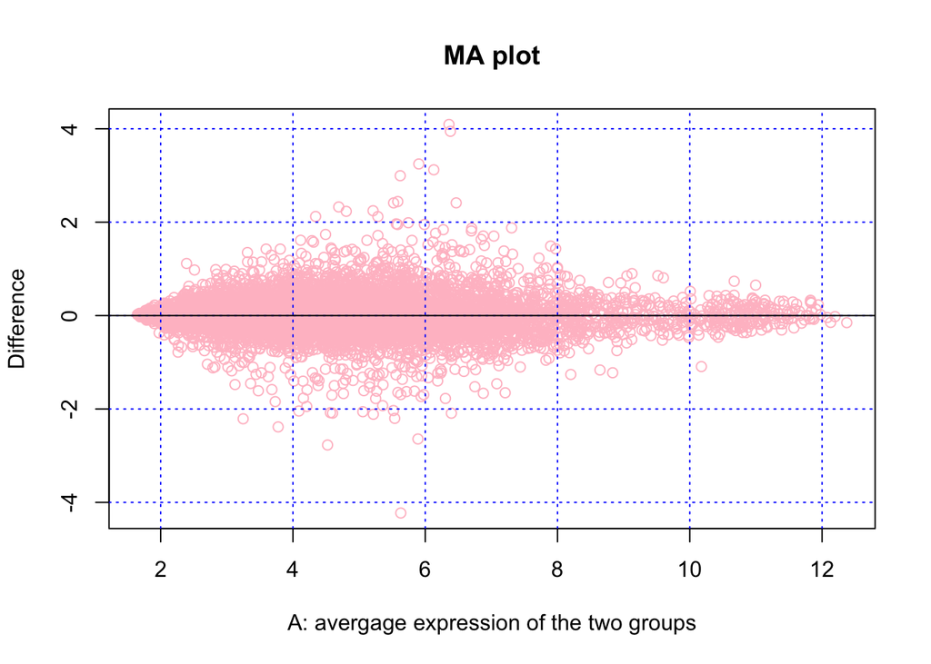

```r
## Calcul de la différence de moyennes par gène entre les deux groupes (M)
M <- mean.per.gene.group2 - mean.per.gene.group1

## Calcul du niveau moyen d'expression des deux groupes (A)
A <- (mean.per.gene.group2 + mean.per.gene.group1)/2


## Dessin d'un plot MA
plot(A, M, col= "pink", main= "MA plot", xlab= "A: avergage expression of the two groups", ylab= "Difference")
grid(col="blue")
abline(h=0) ## Afficher l'axe correspondant à l'hypothèse nulle
```

## Principe du test de Student

http://pedagogix-tagc.univ-mrs.fr/courses/ASG1/practicals/microarrays_student_test/Student_test_info.html